# Where in the world is Taylor paddling?

A heatmap based on paddling workouts recorded on my Garmin watch

Taylor true  
2025-02-17

# Introduction

Over the past two years, I’ve logged dozens of paddling workouts with my Garmin watch. I wanted to learn more about my paddling habits over the past year, so I downloaded my Garmin data in multiple formats to use for analyses below. Read till the end to learn how I made a heatmap showing all the areas I paddled in 2024!

# Acquiring the data

As any data person will tell you, acquiring the data is usually the most tedious part - and it was. I first logged into Garmin Connect and use their advanced search function to generate a .csv of all my paddling workouts in 2024. This part was easy. But of course I can never do anything basic, so I had to get fancy and I wanted GPS data to do that.

In order to get the GPS data I wanted, I had to log into my Garmin account, filter my activities to water sports, and navigate to each individual recorded activity in order to download it as a GPX file. This was in order to preserve the location data associated with each activity, which is not available in the summary .csv I had originally downloaded.

# General stats

| Metric | Value |
| --- | --- |
| Total Distance Paddled (miles) | 603.93 |
| Total Hours Paddled | 120.41 |
| Number of Sessions | 87 |
| Average Distance per Session (miles) | 6.94 |
| Average Duration per Session (mins) | 83.04 |
| Earliest Start Time of Day | 06:23:11 |
| Latest End Time of Day | 11:27:01 |
| Total Calories Burned | 46942 |
| Average Heart Rate (bpm) | 141.2 |
| Max Heart Rate (bpm) | 211 |
| Total Strokes | 271583 |

On a side note, I don’t believe the metric “Latest end time of day” is correct. If it’s 11pm, that’s wayyy too late to be on the water. If it’s 11am, that’s far too early to be off the water, because most of our practices are in the evenings. I’m sure something just got recorded wrong there.

# Trends & insights

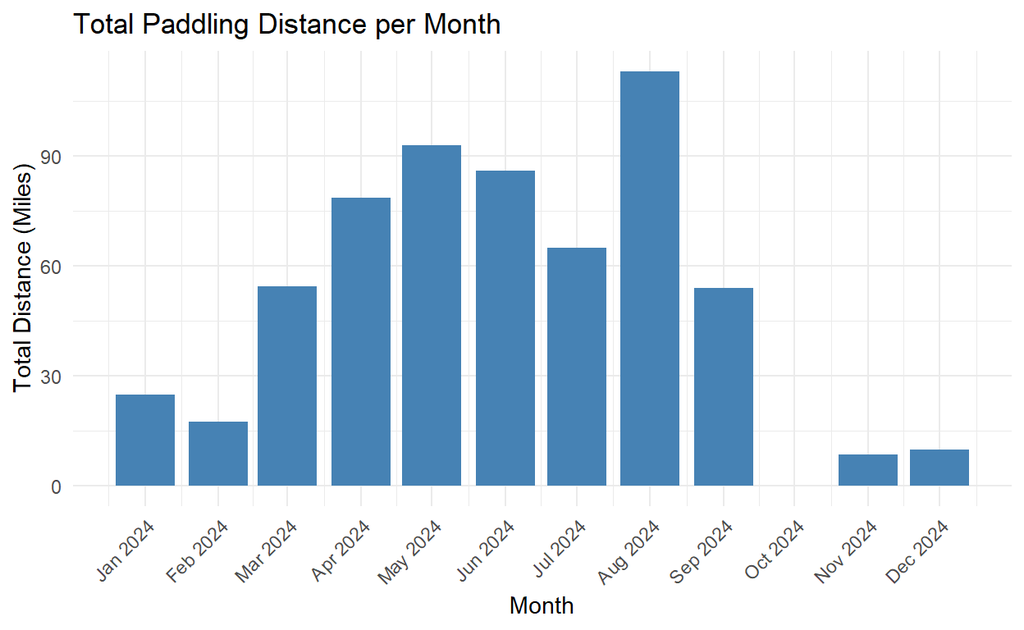

Quite a normal distribution until we get to change season! And you can bet your ass I did absolutely zero paddling in October. A girl’s gotta rest.

# Processing GPS data

Once I had an individual file for each activity (87 in total!), I had to aggregate it all into one file. I did this in a separate processing script, so that I could save one small, efficient file to this website and its associated GitHub repo. The code below will not run, it’s just to showcase how I did this processing. Here is how to process raw Garmin GPX files into usable spatial data:

```r
library(sf)
library(xml2)
library(dplyr)
library(purrr)
library(lubridate)
library(jsonlite)

# Define the folder containing GPX files
gpx_folder <- "data/2024 Garmin Data/"

# Get a list of all GPX files in the folder
gpx_files <- list.files(gpx_folder, pattern = "\\.gpx$", full.names = TRUE)
print(gpx_files)  # This should show a list of file paths

# Spot-check
# gpx_sample <- read_xml(gpx_files[1])  # Read first file to make sure it worked
# print(gpx_sample)

# Now use a function to parse all of the GPX files:
extract_gpx_distance <- function(file) {
  gpx <- read_xml(file) %>% xml_ns_strip()  # Strip namespace

  coords <- gpx %>%
    xml_find_all("//trkpt") %>%
    map_df(~data.frame(
      Latitude = as.numeric(xml_attr(.x, "lat")),
      Longitude = as.numeric(xml_attr(.x, "lon")),
      Timestamp = xml_text(xml_find_first(.x, "time")),  # Extract timestamp
      File = basename(file)  # Keep track of source file
    ))

  if (nrow(coords) < 2) {
    return(NULL)  # Skip files with too few points
  }

  # Convert Timestamp to proper datetime format
  coords <- coords %>%
    mutate(
      Timestamp = ymd_hms(Timestamp),  # Convert to POSIXct
      Date = as.Date(Timestamp)  # Extract Date separately
    ) %>%
    arrange(Timestamp)  # Ensure chronological order

  # Compute distances between consecutive points
  coords <- coords %>%
    mutate(
      Distance_m = c(0, distHaversine(cbind(Longitude[-n()], Latitude[-n()]),
                                      cbind(Longitude[-1], Latitude[-1]))),  # Compute distances
      Cumulative_Distance_km = cumsum(Distance_m) / 1000  # Convert meters to km
    )

  return(coords)
}

# Run the function on all files
all_gpx_data <- map_df(gpx_files, extract_gpx_distance)

# Save data for future use
write.csv(all_gpx_data, "2024_paddling_routes.csv", row.names = FALSE)

# Convert to a spatial object
paddling_sf <- st_as_sf(all_gpx_data, coords = c("Longitude", "Latitude"), crs = 4326)

# Save as GeoJSON
st_write(paddling_sf, "paddling_data.geojson", driver = "GeoJSON", append = FALSE)
```

And voila! Now I have a GeoJSON file available to make fun maps with!

# Spatial heatmap

Once the data was in a workable format, I used `leaflet` to develop the following heatmap. Warmer colors indicate places where I’ve paddled more. Be sure to zoom in, as the map is interactive!

[interactive chart not shown]

# Conclusion

This was such a fun way to explore my paddling history and stats in 2024! Next, I’d love to explore integrating real-time water conditions. What other insights should I look for?